# Project 1: Wrangling, Exploration, Visualization

SDS322E

## Data Wrangling, Exploration, Visualization

### Sarah Lucas sml3855

#### Introduction

The datasets for this project were state-wide datasets compiled by FiveThirtyEight. The ‘hate_crimes’ dataset includes variables thought to influence hate crime incidence, namely socioeconomic factors like higher education, diversity, income inequality, economic measures, etc. The ‘bad_drivers’ dataset takes a look at the number of fatal car crashes by state, causes behind the fatal car crashes, insurance premiums, and insurance losses. I was interested in these datasets because both of these topics are relevant to me and I thought there was a good chance for relationships to emerge by state. I also liked that there was a plethora of numeric variables in each dataset for manipulation.

```r
hate_crimes <- hate_crimes
head(hate_crimes)
```

```
## # A tibble: 6 x 13
##   state state_abbrev median_house_inc share_unemp_seas share_pop_metro
##   <chr> <chr>                   <int>            <dbl>           <dbl>
## 1 Alab… AL                      42278            0.06             0.64
## 2 Alas… AK                      67629            0.064            0.63
## 3 Ariz… AZ                      49254            0.063            0.9
## 4 Arka… AR                      44922            0.052            0.69
## 5 Cali… CA                      60487            0.059            0.97
## 6 Colo… CO                      60940            0.04             0.8
## # … with 8 more variables: share_pop_hs <dbl>, share_non_citizen <dbl>,
## #   share_white_poverty <dbl>, gini_index <dbl>, share_non_white <dbl>,
## #   share_vote_trump <dbl>, hate_crimes_per_100k_splc <dbl>,
## #   avg_hatecrimes_per_100k_fbi <dbl>
```

```r
bad_drivers <- bad_drivers
head(bad_drivers)
```

```
## # A tibble: 6 x 8
##   state num_drivers perc_speeding perc_alcohol perc_not_distra… perc_no_previous
##   <chr>       <dbl>         <int>        <int>            <int>            <int>
## 1 Alab…        18.8            39           30               96               80
## 2 Alas…        18.1            41           25               90               94
## 3 Ariz…        18.6            35           28               84               96
## 4 Arka…        22.4            18           26               94               95
## 5 Cali…        12              35           28               91               89
## 6 Colo…        13.6            37           28               79               95
## # … with 2 more variables: insurance_premiums <dbl>, losses <dbl>
```

#### Tidying: Reshaping

The datasets were already tidy, so I chose to reshape ‘bad_drivers’ by grouping together data from two forms of accidents resulting from actual law violations: drivers under the influence of alcohol (‘perc_alcohol’) and drivers who broke the speed limit (‘perc_speeding’). I then reshaped the data to separate out these accidents by speeding and alcohol use.

```r
# Untidy by grouping together accidents from law violations
bad_drivers_long <- bad_drivers %>% pivot_longer(3:4, names_to = "law_violation",
    values_to = "perc")
bad_drivers_long
```

```
## # A tibble: 102 x 8
##    state num_drivers perc_not_distra… perc_no_previous insurance_premi… losses
##    <chr>       <dbl>            <int>            <int>            <dbl>  <dbl>
##  1 Alab…        18.8               96               80             785.   145.
##  2 Alab…        18.8               96               80             785.   145.
##  3 Alas…        18.1               90               94            1053.   134.
##  4 Alas…        18.1               90               94            1053.   134.
##  5 Ariz…        18.6               84               96             899.   110.
##  6 Ariz…        18.6               84               96             899.   110.
##  7 Arka…        22.4               94               95             827.   142.
##  8 Arka…        22.4               94               95             827.   142.
##  9 Cali…        12                 91               89             878.   166.
## 10 Cali…        12                 91               89             878.   166.
## # … with 92 more rows, and 2 more variables: law_violation <chr>, perc <int>
```

```r
# Retidy by separating out accidents by speeding and alcohol
# use
bad_drivers_long %>% pivot_wider(names_from = "law_violation",
    values_from = "perc")
```

```
## # A tibble: 51 x 8
##    state num_drivers perc_not_distra… perc_no_previous insurance_premi… losses
##    <chr>       <dbl>            <int>            <int>            <dbl>  <dbl>
##  1 Alab…        18.8               96               80             785.   145.
##  2 Alas…        18.1               90               94            1053.   134.
##  3 Ariz…        18.6               84               96             899.   110.
##  4 Arka…        22.4               94               95             827.   142.
##  5 Cali…        12                 91               89             878.   166.
##  6 Colo…        13.6               79               95             836.   140.
##  7 Conn…        10.8               87               82            1069.   167.
##  8 Dela…        16.2               87               99            1138.   151.
##  9 Dist…         5.9              100              100            1274.   136.
## 10 Flor…        17.9               92               94            1160.   144.
## # … with 41 more rows, and 2 more variables: perc_speeding <int>,
## #   perc_alcohol <int>
```

#### Joining/Merging

```r
comb_data <- full_join(hate_crimes, bad_drivers, by = "state")
```

A full join was performed using the common variable ‘state’. The original ‘hate_crimes’ dataset had 51 observations with 51 distinct IDs. The original ‘bad_drivers’ dataset had 51 observations with 51 distinct IDs. Both datasets had 51 IDs to account for the fact that they are culled from state data. As such, there were no unique IDs in either dataset nor IDs that appeared in only one dataset – the datasets had all IDs in common. I chose this particular join because I wanted to retain all data from both datasets. No rows were dropped in the joined dataset.

#### Wrangling

```r
comb_data <- comb_data %>% select(-state_abbrev)

comb_data %>% summarize(mean_num_drivers = mean(num_drivers,
    na.rm = T), sd_num_drivers = sd(num_drivers, na.rm = T),
    med_num_drivers = median(num_drivers, na.rm = T), min_num_drivers = min(num_drivers,
        na.rm = T), max_num_drivers = max(num_drivers, na.rm = T))
```

```
## # A tibble: 1 x 5
##   mean_num_drivers sd_num_drivers med_num_drivers min_num_drivers
##              <dbl>          <dbl>           <dbl>           <dbl>
## 1             15.8           4.12            15.6             5.9
## # … with 1 more variable: max_num_drivers <dbl>
```

```r
comb_data %>% arrange(desc(num_drivers))
```

```
## # A tibble: 51 x 19
##    state median_house_inc share_unemp_seas share_pop_metro share_pop_hs
##    <chr>            <int>            <dbl>           <dbl>        <dbl>
##  1 Nort…            60730            0.028            0.5         0.901
##  2 Sout…            44929            0.057            0.79        0.836
##  3 West…            39552            0.073            0.55        0.828
##  4 Arka…            44922            0.052            0.69        0.824
##  5 Kent…            42786            0.05             0.56        0.817
##  6 Mont…            51102            0.041            0.34        0.908
##  7 Loui…            42406            0.06             0.81        0.822
##  8 Okla…            47199            0.044            0.59        0.856
##  9 Tenn…            43716            0.057            0.82        0.831
## 10 Sout…            53053            0.035            0.51        0.899
## # … with 41 more rows, and 14 more variables: share_non_citizen <dbl>,
## #   share_white_poverty <dbl>, gini_index <dbl>, share_non_white <dbl>,
## #   share_vote_trump <dbl>, hate_crimes_per_100k_splc <dbl>,
## #   avg_hatecrimes_per_100k_fbi <dbl>, num_drivers <dbl>, perc_speeding <int>,
## #   perc_alcohol <int>, perc_not_distracted <int>, perc_no_previous <int>,
## #   insurance_premiums <dbl>, losses <dbl>
```

```r
comb_data %>% filter(state == "North Dakota")
```

```
## # A tibble: 1 x 19
##   state median_house_inc share_unemp_seas share_pop_metro share_pop_hs
##   <chr>            <int>            <dbl>           <dbl>        <dbl>
## 1 Nort…            60730            0.028             0.5        0.901
## # … with 14 more variables: share_non_citizen <dbl>, share_white_poverty <dbl>,
## #   gini_index <dbl>, share_non_white <dbl>, share_vote_trump <dbl>,
## #   hate_crimes_per_100k_splc <dbl>, avg_hatecrimes_per_100k_fbi <dbl>,
## #   num_drivers <dbl>, perc_speeding <int>, perc_alcohol <int>,
## #   perc_not_distracted <int>, perc_no_previous <int>,
## #   insurance_premiums <dbl>, losses <dbl>
```

```r
comb_data %>% group_by(state) %>% arrange(perc_not_distracted)
```

```
## # A tibble: 51 x 19
## # Groups:   state [51]
##    state median_house_inc share_unemp_seas share_pop_metro share_pop_hs
##    <chr>            <int>            <dbl>           <dbl>        <dbl>
##  1 Miss…            35521            0.061            0.45        0.804
##  2 Wisc…            58080            0.043            0.69        0.898
##  3 New …            46686            0.068            0.69        0.828
##  4 Oreg…            58875            0.062            0.87        0.891
##  5 Mary…            76165            0.051            0.97        0.89
##  6 Loui…            42406            0.06             0.81        0.822
##  7 Kans…            53444            0.044            0.64        0.897
##  8 Kent…            42786            0.05             0.56        0.817
##  9 Colo…            60940            0.04             0.8         0.893
## 10 Wyom…            55690            0.04             0.31        0.918
## # … with 41 more rows, and 14 more variables: share_non_citizen <dbl>,
## #   share_white_poverty <dbl>, gini_index <dbl>, share_non_white <dbl>,
## #   share_vote_trump <dbl>, hate_crimes_per_100k_splc <dbl>,
## #   avg_hatecrimes_per_100k_fbi <dbl>, num_drivers <dbl>, perc_speeding <int>,
## #   perc_alcohol <int>, perc_not_distracted <int>, perc_no_previous <int>,
## #   insurance_premiums <dbl>, losses <dbl>
```

```r
# Create new variable combining two original variables
comb_data <- comb_data %>% mutate(perc_irresponsible = perc_speeding +
    perc_alcohol)
comb_data %>% arrange(desc(perc_irresponsible))
```

```
## # A tibble: 51 x 20
##    state median_house_inc share_unemp_seas share_pop_metro share_pop_hs
##    <chr>            <int>            <dbl>           <dbl>        <dbl>
##  1 Hawa…            71223            0.034            0.76        0.904
##  2 Mont…            51102            0.041            0.34        0.908
##  3 Conn…            70161            0.052            0.94        0.886
##  4 Penn…            55173            0.053            0.87        0.879
##  5 Sout…            44929            0.057            0.79        0.836
##  6 Texas            53875            0.042            0.92        0.799
##  7 Miss…            56630            0.053            0.78        0.868
##  8 Wash…            59068            0.052            0.86        0.897
##  9 Wyom…            55690            0.04             0.31        0.918
## 10 Rhod…            58633            0.054            1           0.847
## # … with 41 more rows, and 15 more variables: share_non_citizen <dbl>,
## #   share_white_poverty <dbl>, gini_index <dbl>, share_non_white <dbl>,
## #   share_vote_trump <dbl>, hate_crimes_per_100k_splc <dbl>,
## #   avg_hatecrimes_per_100k_fbi <dbl>, num_drivers <dbl>, perc_speeding <int>,
## #   perc_alcohol <int>, perc_not_distracted <int>, perc_no_previous <int>,
## #   insurance_premiums <dbl>, losses <dbl>, perc_irresponsible <int>
```

```r
comb_data %>% summarize(mean_perc_speeding = mean(perc_speeding,
    na.rm = T), sd_perc_speeding = sd(perc_speeding, na.rm = T),
    med_perc_speeding = median(perc_speeding, na.rm = T), min_perc_speeding = min(perc_speeding,
        na.rm = T), max_perc_speeding = max(perc_speeding, na.rm = T))
```

```
## # A tibble: 1 x 5
##   mean_perc_speed… sd_perc_speeding med_perc_speedi… min_perc_speedi…
##              <dbl>            <dbl>            <int>            <int>
## 1             31.7             9.63               34               13
## # … with 1 more variable: max_perc_speeding <int>
```

```r
comb_data %>% summarize(mean_perc_alcohol = mean(perc_alcohol,
    na.rm = T), sd_perc_alcohol = sd(perc_alcohol, na.rm = T),
    med_perc_alcohol = median(perc_alcohol, na.rm = T), min_perc_alcohol = min(perc_alcohol,
        na.rm = T), max_perc_alcohol = max(perc_alcohol, na.rm = T))
```

```
## # A tibble: 1 x 5
##   mean_perc_alcoh… sd_perc_alcohol med_perc_alcohol min_perc_alcohol
##              <dbl>           <dbl>            <int>            <int>
## 1             30.7            5.13               30               16
## # … with 1 more variable: max_perc_alcohol <int>
```

```r
comb_data %>% summarize(mean_insurance_premiums = mean(insurance_premiums,
    na.rm = T), sd_insurance_premiums = sd(insurance_premiums,
    na.rm = T), med_insurance_premiums = median(insurance_premiums,
    na.rm = T), min_insurance_premiums = min(insurance_premiums,
    na.rm = T), max_insurance_premiums = max(insurance_premiums,
    na.rm = T))
```

```
## # A tibble: 1 x 5
##   mean_insurance_… sd_insurance_pr… med_insurance_p… min_insurance_p…
##              <dbl>            <dbl>            <dbl>            <dbl>
## 1             887.             178.             859.             642.
## # … with 1 more variable: max_insurance_premiums <dbl>
```

```r
comb_data %>% filter(insurance_premiums == 1301.52)  #find state with maximum insurance premium
```

```
## # A tibble: 1 x 20
##   state median_house_inc share_unemp_seas share_pop_metro share_pop_hs
##   <chr>            <int>            <dbl>           <dbl>        <dbl>
## 1 New …            65243            0.056               1        0.874
## # … with 15 more variables: share_non_citizen <dbl>, share_white_poverty <dbl>,
## #   gini_index <dbl>, share_non_white <dbl>, share_vote_trump <dbl>,
## #   hate_crimes_per_100k_splc <dbl>, avg_hatecrimes_per_100k_fbi <dbl>,
## #   num_drivers <dbl>, perc_speeding <int>, perc_alcohol <int>,
## #   perc_not_distracted <int>, perc_no_previous <int>,
## #   insurance_premiums <dbl>, losses <dbl>, perc_irresponsible <int>
```

```r
comb_data %>% summarize(mean_gini_index = mean(gini_index, na.rm = T),
    sd_gini_index = sd(gini_index, na.rm = T), med_gini_index = median(gini_index,
        na.rm = T), min_gini_index = min(gini_index, na.rm = T),
    max_gini_index = max(gini_index, na.rm = T))
```

```
## # A tibble: 1 x 5
##   mean_gini_index sd_gini_index med_gini_index min_gini_index max_gini_index
##             <dbl>         <dbl>          <dbl>          <dbl>          <dbl>
## 1           0.454        0.0209          0.454          0.419          0.532
```

```r
comb_data %>% summarize(mean_avg_hatecrimes_per_100k_fbi = mean(avg_hatecrimes_per_100k_fbi,
    na.rm = T), sd_avg_hatecrimes_per_100k_fbi = sd(avg_hatecrimes_per_100k_fbi,
    na.rm = T), med_avg_hatecrimes_per_100k_fbi = median(avg_hatecrimes_per_100k_fbi,
    na.rm = T), min_avg_hatecrimes_per_100k_fbi = min(avg_hatecrimes_per_100k_fbi,
    na.rm = T), max_avg_hatecrimes_per_100k_fbi = max(avg_hatecrimes_per_100k_fbi,
    na.rm = T))
```

```
## # A tibble: 1 x 5
##   mean_avg_hatecr… sd_avg_hatecrim… med_avg_hatecri… min_avg_hatecri…
##              <dbl>            <dbl>            <dbl>            <dbl>
## 1             2.37             1.71             1.99            0.267
## # … with 1 more variable: max_avg_hatecrimes_per_100k_fbi <dbl>
```

```r
# Create categorical variable
comb_data <- comb_data %>% mutate(gini_index_rank = case_when(gini_index >
    0.5 ~ "high", gini_index <= 0.5 & 0.4 <= gini_index ~ "med",
    gini_index < 0.4 ~ "low"))
comb_data
```

```
## # A tibble: 51 x 21
##    state median_house_inc share_unemp_seas share_pop_metro share_pop_hs
##    <chr>            <int>            <dbl>           <dbl>        <dbl>
##  1 Alab…            42278            0.06             0.64        0.821
##  2 Alas…            67629            0.064            0.63        0.914
##  3 Ariz…            49254            0.063            0.9         0.842
##  4 Arka…            44922            0.052            0.69        0.824
##  5 Cali…            60487            0.059            0.97        0.806
##  6 Colo…            60940            0.04             0.8         0.893
##  7 Conn…            70161            0.052            0.94        0.886
##  8 Dela…            57522            0.049            0.9         0.874
##  9 Dist…            68277            0.067            1           0.871
## 10 Flor…            46140            0.052            0.96        0.853
## # … with 41 more rows, and 16 more variables: share_non_citizen <dbl>,
## #   share_white_poverty <dbl>, gini_index <dbl>, share_non_white <dbl>,
## #   share_vote_trump <dbl>, hate_crimes_per_100k_splc <dbl>,
## #   avg_hatecrimes_per_100k_fbi <dbl>, num_drivers <dbl>, perc_speeding <int>,
## #   perc_alcohol <int>, perc_not_distracted <int>, perc_no_previous <int>,
## #   insurance_premiums <dbl>, losses <dbl>, perc_irresponsible <int>,
## #   gini_index_rank <chr>
```

```r
# Report counts of created categorical variable
comb_data %>% group_by(gini_index_rank) %>% summarize(n())
```

```
## # A tibble: 2 x 2
##   gini_index_rank `n()`
##   <chr>           <int>
## 1 high                1
## 2 med                50
```

```r
# Stringr
comb_data %>% distinct(state) %>% slice_min(str_length(state))
```

```
## # A tibble: 3 x 1
##   state
##   <chr>
## 1 Iowa
## 2 Ohio
## 3 Utah
```

```r
comb_data %>% distinct(state) %>% summarize(num_a = sum(str_detect(state,
    "a")))
```

```
## # A tibble: 1 x 1
##   num_a
##   <int>
## 1    37
```

```r
# Define Percent irresponsible function
perc_irresponsible_conv <- function(perc_irresponsible) {
    perc_irresponsible_conv <- (perc_irresponsible/100)
    return(perc_irresponsible_conv)
}
comb_data %>% mutate(perc_irresponsible_dec = perc_irresponsible_conv(perc_irresponsible))
```

```
## # A tibble: 51 x 22
##    state median_house_inc share_unemp_seas share_pop_metro share_pop_hs
##    <chr>            <int>            <dbl>           <dbl>        <dbl>
##  1 Alab…            42278            0.06             0.64        0.821
##  2 Alas…            67629            0.064            0.63        0.914
##  3 Ariz…            49254            0.063            0.9         0.842
##  4 Arka…            44922            0.052            0.69        0.824
##  5 Cali…            60487            0.059            0.97        0.806
##  6 Colo…            60940            0.04             0.8         0.893
##  7 Conn…            70161            0.052            0.94        0.886
##  8 Dela…            57522            0.049            0.9         0.874
##  9 Dist…            68277            0.067            1           0.871
## 10 Flor…            46140            0.052            0.96        0.853
## # … with 41 more rows, and 17 more variables: share_non_citizen <dbl>,
## #   share_white_poverty <dbl>, gini_index <dbl>, share_non_white <dbl>,
## #   share_vote_trump <dbl>, hate_crimes_per_100k_splc <dbl>,
## #   avg_hatecrimes_per_100k_fbi <dbl>, num_drivers <dbl>, perc_speeding <int>,
## #   perc_alcohol <int>, perc_not_distracted <int>, perc_no_previous <int>,
## #   insurance_premiums <dbl>, losses <dbl>, perc_irresponsible <int>,
## #   gini_index_rank <chr>, perc_irresponsible_dec <dbl>
```

```r
# number of NAs for each variable
comb_data %>% summarize_all(function(x) sum(is.na(x)))
```

```
## # A tibble: 1 x 21
##   state median_house_inc share_unemp_seas share_pop_metro share_pop_hs
##   <int>            <int>            <int>           <int>        <int>
## 1     0                0                0               0            0
## # … with 16 more variables: share_non_citizen <int>, share_white_poverty <int>,
## #   gini_index <int>, share_non_white <int>, share_vote_trump <int>,
## #   hate_crimes_per_100k_splc <int>, avg_hatecrimes_per_100k_fbi <int>,
## #   num_drivers <int>, perc_speeding <int>, perc_alcohol <int>,
## #   perc_not_distracted <int>, perc_no_previous <int>,
## #   insurance_premiums <int>, losses <int>, perc_irresponsible <int>,
## #   gini_index_rank <int>
```

States with the Top 5 Highest Premiums

```r
comb_data %>% select(1, 18) %>% slice_max(insurance_premiums,
    n = 5)
```

```
## # A tibble: 5 x 2
##   state                insurance_premiums
##   <chr>                             <dbl>
## 1 New Jersey                        1302.
## 2 Louisiana                         1282.
## 3 District of Columbia              1274.
## 4 New York                          1234.
## 5 Florida                           1160.
```

```r
comb_data %>% filter(state %in% c("New Jersey", "Louisiana",
    "District of Columbia", "New York", "Florida")) %>% group_by(state) %>%
    na.omit() %>% summarize(mean_insurance_premiums = mean(insurance_premiums,
    na.rm = T), med_insurance_premiums = median(insurance_premiums,
    na.rm = T), min_insurance_premiums = min(insurance_premiums,
    na.rm = T), max_insurance_premiums = max(insurance_premiums,
    na.rm = T)) %>% arrange(mean_insurance_premiums) %>% kable(digits = 3,
    align = "c")
```

| state | mean_insurance_premiums | med_insurance_premiums | min_insurance_premiums | max_insurance_premiums |
| --- | --- | --- | --- | --- |
| Florida | 1160.13 | 1160.13 | 1160.13 | 1160.13 |
| New York | 1234.31 | 1234.31 | 1234.31 | 1234.31 |
| District of Columbia | 1273.89 | 1273.89 | 1273.89 | 1273.89 |
| Louisiana | 1281.55 | 1281.55 | 1281.55 | 1281.55 |
| New Jersey | 1301.52 | 1301.52 | 1301.52 | 1301.52 |

I used ‘select’ to get rid of ‘state_abbrev’ from the original joined dataset, since its function is redundant with the ‘state’ variable. Next, I calculated summary statistics on the number of drivers in fatal collisions by state. Using ‘arange’, I found that the state with the highest number of drivers involved in fatal accidents was North Dakota. At 23.9 drivers involved in fatal collisions per billion miles travelled, North Dakota stands well above the national average of 15.7. But how culpable are the the drivers in states with high numbers of crashes? Let’s take North Dakota again using ‘filter’. I created a function, ‘perc_irresponsible_conv’ to convert the percent of drivers engaging in irresponsible behavior to a decimal value, which I later used in one of my plots. I found that in spite of the high number of crashes compared to the national average, only 1% of crashes in North Dakota were due to distracted driving. North Dakota’s percentage of undistracted drivers in fatal collisions is the second-highest of the dataset (tied with Ohio and behind D.C.). By contrast, 90% of fatal crashes in Mississippi resulted from distracted driving. Another way to think about bad drivers is by looking at insurance premium prices. By this measure, New Jersey has the worst drivers, with insurance premiums of $1302 (verified using ‘filter’). This is well above the national average of $887. I then collected summary statistics from the variables capturing illegal driving, ‘perc_alcohol’ and ‘perc_speeding.’

#### Visualizing

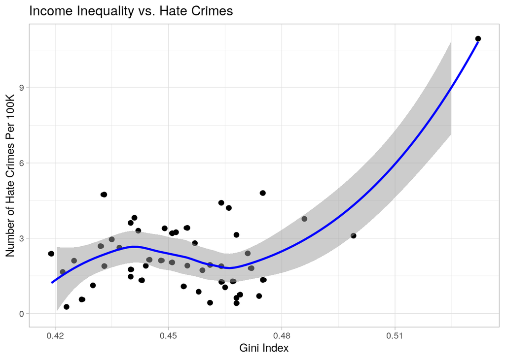

```r
comb_data %>% ggplot(aes(x = gini_index, y = avg_hatecrimes_per_100k_fbi)) +
    geom_point(size = 2) + geom_jitter() + geom_smooth(alpha = 0.5,
    color = "blue") + labs(title = "Income Inequality vs. Hate Crimes") +
    xlab("Gini Index") + scale_x_continuous() + ylab("Number of Hate Crimes Per 100K") +
    scale_y_continuous(lim = c(0, 11)) + theme_light()
```

In Plot #1, I graphed Gini Index values per state versus the number of hate crimes per 100,000 people. There is a weak positive correlation between these two variables – as Gini Index values increase (indicating greater inequality), the number of hate crimes recorded also increased. There was also one clear outlier, captured earlier in the categorical variable ‘gini_index_rank’ as the only ‘high’ Gini Index value (above 0.5). This data point corresponds to D.C. This observation does not imply causation between the two variables. This finding is in line with prior research on crime that posits income inequality as a contributor towards violence.

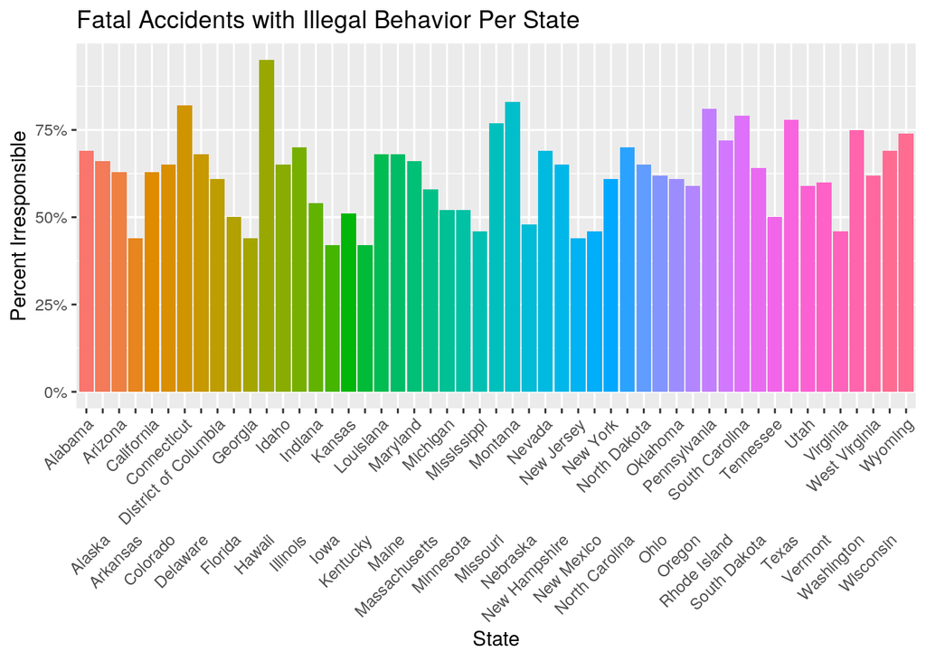

```r
comb_data %>% mutate(perc_irr_conv = perc_irresponsible/100) %>%
    ggplot(aes(state)) + geom_bar(aes(y = perc_irr_conv, fill = state),
    stat = "summary", fun = mean) + scale_x_discrete(guide = guide_axis(n.dodge = 2)) +
    labs(title = "Fatal Accidents with Illegal Behavior Per State") +
    xlab("State") + ylab("Percent Irresponsible") + scale_y_continuous(labels = scales::percent) +
    theme(axis.text.x = element_text(angle = 45, hjust = 1),
        legend.position = "none")
```

In Plot #2, I returned to my perc_irresponsible variable and graphed it by state. Illegal activity by drinking or speeding is one way to quantify bad driving. The graph shows that the percentage of fatal crashes caused by illegal driving habits does decently fluctuate between states. For the majority of states, the percentage of fatal crashes caused by irresponsible behavior was greater than 50%. Hawaii stands out clearly from other states, with the percentage of fatal crashes caused by irresponsible behavior of 95%.

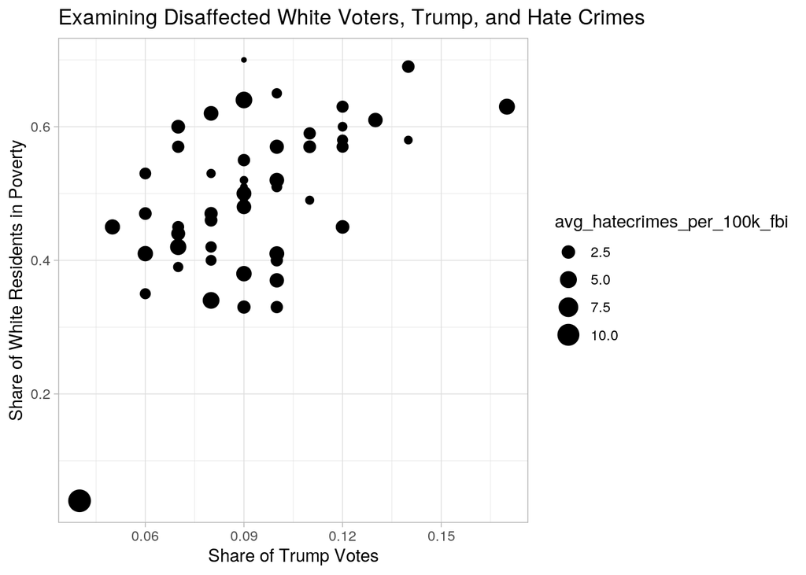

```r
comb_data %>% ggplot(aes(share_white_poverty, share_vote_trump)) +
    geom_point(aes(size = avg_hatecrimes_per_100k_fbi)) + labs(title = "Examining Disaffected White Voters, Trump, and Hate Crimes") +
    xlab("Share of Trump Votes") + scale_x_continuous() + scale_x_continuous() +
    ylab("Share of White Residents in Poverty") + theme_light()
```

In Plot #3, I examined the relationship between a state’s share of the population that voted for Trump and the share of white residents in poverty. I was interested in examining this relationship because Trump’s stereotypical base is white working-class voters. The data point size was changed based on the average number of hate crimes per state per 100k people. There appears to be a weak positive correlation between the share of Trump votes and the share of white residents in poverty. I don’t see much of a mediating impact of hate crime incidence on the data: The outlier on the lower end of the x-axis has low values for share of trump votes and share of white residents in poverty yet the highest possible grouping of hate crimes, 10.0/100,000 people.